```python
import numpy as np
import pandas as pd
import matplotlib.pyplot as plt
import seaborn as sns
sns.set()

from IPython.core.interactiveshell import InteractiveShell
InteractiveShell.ast_node_interactivity = "all"

file = "C://Users/brown/Desktop/MSDS/Practical Machine Learning/Assignment 1/HMEQ_Loss.csv"

df = pd.read_csv(file)
```

# Explore Dataset

```python
df.head().T
```

|  | 0 | 1 | 2 | 3 | 4 |
| --- | --- | --- | --- | --- | --- |
| TARGET_BAD_FLAG | 1 | 1 | 1 | 1 | 0 |
| TARGET_LOSS_AMT | 641 | 1109 | 767 | 1425 | NaN |
| LOAN | 1100 | 1300 | 1500 | 1500 | 1700 |
| MORTDUE | 25860 | 70053 | 13500 | NaN | 97800 |
| VALUE | 39025 | 68400 | 16700 | NaN | 112000 |
| REASON | HomeImp | HomeImp | HomeImp | NaN | HomeImp |
| JOB | Other | Other | Other | NaN | Office |
| YOJ | 10.5 | 7 | 4 | NaN | 3 |
| DEROG | 0 | 0 | 0 | NaN | 0 |
| DELINQ | 0 | 2 | 0 | NaN | 0 |
| CLAGE | 94.3667 | 121.833 | 149.467 | NaN | 93.3333 |
| NINQ | 1 | 0 | 1 | NaN | 0 |
| CLNO | 9 | 14 | 10 | NaN | 14 |
| DEBTINC | NaN | NaN | NaN | NaN | NaN |

```python
dflt = "TARGET_BAD_FLAG"
amt = "TARGET_LOSS_AMT"
```

```python
x = df.describe().T

x['iqr'] = x['75%'] - x['25%']

x['l_outlier'] = x['25%'] - (1.5 * x['iqr'])
x['l_extreme'] = x['25%'] - (3 * x['iqr'])

x['u_outlier'] = x['25%'] + (1.5 * x['iqr'])
x['u_extreme'] = x['25%'] + (3 * x['iqr'])

#Set lower outlier/extreme boundaries to 0 if negative since none of our numerical values should be negative.
x['l_outlier'] = x['l_outlier'].apply(lambda x: x if x >= 0 else 0)
x['l_extreme'] = x['l_extreme'].apply(lambda x: x if x >= 0 else 0)

x.round(2)
```

|  | count | mean | std | min | 25% | 50% | 75% | max | iqr | l_outlier | l_extreme | u_outlier | u_extreme |
| --- | --- | --- | --- | --- | --- | --- | --- | --- | --- | --- | --- | --- | --- |
| TARGET_BAD_FLAG | 5960.0 | 0.20 | 0.40 | 0.00 | 0.00 | 0.00 | 0.00 | 1.00 | 0.00 | 0.00 | 0.0 | 0.00 | 0.00 |
| TARGET_LOSS_AMT | 1189.0 | 13414.58 | 10839.46 | 224.00 | 5639.00 | 11003.00 | 17634.00 | 78987.00 | 11995.00 | 0.00 | 0.0 | 23631.50 | 41624.00 |
| LOAN | 5960.0 | 18607.97 | 11207.48 | 1100.00 | 11100.00 | 16300.00 | 23300.00 | 89900.00 | 12200.00 | 0.00 | 0.0 | 29400.00 | 47700.00 |
| MORTDUE | 5442.0 | 73760.82 | 44457.61 | 2063.00 | 46276.00 | 65019.00 | 91488.00 | 399550.00 | 45212.00 | 0.00 | 0.0 | 114094.00 | 181912.00 |
| VALUE | 5848.0 | 101776.05 | 57385.78 | 8000.00 | 66075.50 | 89235.50 | 119824.25 | 855909.00 | 53748.75 | 0.00 | 0.0 | 146698.62 | 227321.75 |
| YOJ | 5445.0 | 8.92 | 7.57 | 0.00 | 3.00 | 7.00 | 13.00 | 41.00 | 10.00 | 0.00 | 0.0 | 18.00 | 33.00 |
| DEROG | 5252.0 | 0.25 | 0.85 | 0.00 | 0.00 | 0.00 | 0.00 | 10.00 | 0.00 | 0.00 | 0.0 | 0.00 | 0.00 |
| DELINQ | 5380.0 | 0.45 | 1.13 | 0.00 | 0.00 | 0.00 | 0.00 | 15.00 | 0.00 | 0.00 | 0.0 | 0.00 | 0.00 |
| CLAGE | 5652.0 | 179.77 | 85.81 | 0.00 | 115.12 | 173.47 | 231.56 | 1168.23 | 116.45 | 0.00 | 0.0 | 289.79 | 464.45 |
| NINQ | 5450.0 | 1.19 | 1.73 | 0.00 | 0.00 | 1.00 | 2.00 | 17.00 | 2.00 | 0.00 | 0.0 | 3.00 | 6.00 |
| CLNO | 5738.0 | 21.30 | 10.14 | 0.00 | 15.00 | 20.00 | 26.00 | 71.00 | 11.00 | 0.00 | 0.0 | 31.50 | 48.00 |
| DEBTINC | 4693.0 | 33.78 | 8.60 | 0.52 | 29.14 | 34.82 | 39.00 | 203.31 | 9.86 | 14.35 | 0.0 | 43.93 | 58.73 |

**Target Variables:**  
The count and mean of the default flag tells us that out of 5960 loans in the dataset, about 20% defaulted (mean of binary input = .1995). The mean loss amount is \$13,415 and the median is \\$11,003, however, the maximum is \$78,987 which suggests that we have some extreme outliers to deal with (upper boundary for extreme outliers is \\$41,624)  
**Input Variables:**  
Every numerical input value contains extreme upper outliers that we'll have to determine what to do with as we build the predictive model. One interesting thing to note is Derogatory marks and Delinquencies both look like they're heavily skewed to the right as the majority of the loan recipients have 0 of each with maximums of 10 and 15 respectively.

```python
dt = df.dtypes
#dt

# Change LOAN to float just to consolidate numerical values.
df['LOAN'] = df['LOAN'].astype('float64')
dt = df.dtypes
dt
```

```
TARGET_BAD_FLAG      int64
TARGET_LOSS_AMT    float64
LOAN               float64
MORTDUE            float64
VALUE              float64
REASON              object
JOB                 object
YOJ                float64
DEROG              float64
DELINQ             float64
CLAGE              float64
NINQ               float64
CLNO               float64
DEBTINC            float64
dtype: object
```

```python
objList = []
fltList = []

for var in dt.index:

    if var in ['TARGET_BAD_FLAG','TARGET_LOSS_AMT']:

        continue

    if dt[var] == "object":

        objList.append(var)

    if dt[var] == "float64":

        fltList.append(var)

print("Objects: "+str(objList)[1:-1])

# For each object column, print the unique values that are present
for obj in objList:

    print('     ' + obj + ' Classes: ' + str(df[obj].unique()))

print()
print("Floats: "+str(fltList)[1:-1])
```

```
Objects: 'REASON', 'JOB'
     REASON Classes: ['HomeImp' nan 'DebtCon']
     JOB Classes: ['Other' nan 'Office' 'Sales' 'Mgr' 'ProfExe' 'Self']

Floats: 'LOAN', 'MORTDUE', 'VALUE', 'YOJ', 'DEROG', 'DELINQ', 'CLAGE', 'NINQ', 'CLNO', 'DEBTINC'
```

```python
group = {}

for obj in objList:

    g = df.groupby(by=obj)
    group[obj] = g

for g in group:

    group[g].mean().T
```

| REASON | DebtCon | HomeImp |
| --- | --- | --- |
| TARGET_BAD_FLAG | 0.189664 | 0.222472 |
| TARGET_LOSS_AMT | 16005.163758 | 8388.090909 |
| LOAN | 19952.953157 | 16006.629213 |
| MORTDUE | 74736.549693 | 72029.326495 |
| VALUE | 102172.956197 | 101675.094662 |
| YOJ | 8.632223 | 9.475321 |
| DEROG | 0.255674 | 0.236206 |
| DELINQ | 0.435448 | 0.450307 |
| CLAGE | 175.618944 | 186.414088 |
| NINQ | 1.340321 | 0.863832 |
| CLNO | 22.147898 | 19.601631 |
| DEBTINC | 34.308796 | 33.280063 |

| JOB | Mgr | Office | Other | ProfExe | Sales | Self |
| --- | --- | --- | --- | --- | --- | --- |
| TARGET_BAD_FLAG | 0.233377 | 0.131857 | 0.231993 | 0.166144 | 0.348624 | 0.300518 |
| TARGET_LOSS_AMT | 14141.536313 | 13475.304000 | 11570.102888 | 14660.966981 | 16421.447368 | 22232.362069 |
| LOAN | 19155.280313 | 18142.616034 | 18061.683417 | 18983.463950 | 14913.761468 | 28314.507772 |
| MORTDUE | 82295.007659 | 66757.144265 | 59337.147858 | 94959.637806 | 82266.181818 | 99776.188889 |
| VALUE | 108628.262697 | 94081.816756 | 84787.503377 | 131118.204130 | 108449.592593 | 149734.106383 |
| YOJ | 9.319372 | 8.350438 | 9.459063 | 8.752345 | 6.802020 | 7.069399 |
| DEROG | 0.337386 | 0.151371 | 0.296919 | 0.184564 | 0.444444 | 0.235294 |
| DELINQ | 0.630747 | 0.453196 | 0.420613 | 0.416667 | 0.285714 | 0.578652 |
| CLAGE | 174.483868 | 179.489207 | 173.520162 | 197.914313 | 195.304893 | 174.536225 |
| NINQ | 1.509116 | 0.931188 | 1.323049 | 0.982843 | 0.750000 | 1.357576 |
| CLNO | 22.885638 | 21.191286 | 19.256072 | 24.503195 | 24.880734 | 23.026316 |
| DEBTINC | 35.277869 | 34.330619 | 34.241852 | 32.540668 | 37.534481 | 35.568006 |

**REASON:**  
The first thing of interest here to me is that the rate of Default is slightly less when Debt Consolidation (~19%) is the reason for a loan vs. Home Improvement (~22%). Our conventional wisdom says that DebtCon should be riskier. However, looking at the loss amount, we can see that the average a bank loses for DebtCon loan defaults is nearly double that of HomeImp.  
Additionally, the Loss Amount for DebtCon is nearly equal to the average Loan Amount but for HomeImp is about half of the average Loan Amount.  
**JOB:**  
The job titles here are pretty telling in that those who are 'Self Employed' tend to Default at the 2nd highest rate of 30%, result in the most loss on average and also take out the largest loans on average.  
Also of note is the higher rate of Derogatory Marks for those who are in Sales. Maybe this is due to the instability of a commission-based role. Interestingly, the Delinquencies are much lower than others. With Self Employed individuals, the inverse is true where Delinquencies are high and Derogatory Marks are in the lower half of the 6 Job classes.

# Visualize Default Rate and Loss Amount by Job Type and Reason for Loan

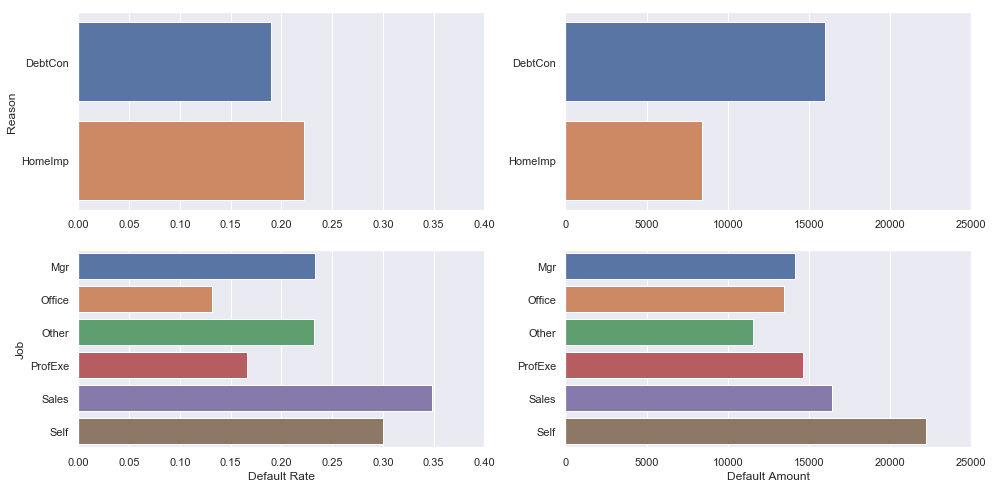

```python
fig, axes = plt.subplots(2, 2, figsize=(16,8))

p1 = sns.barplot(
    y=group['REASON'].mean().index,
    x=group['REASON'].mean()[dflt],
    ax=axes[0,0])

p2 = sns.barplot(
    y=group['REASON'].mean().index,
    x=group['REASON'].mean()[amt],
    ax=axes[0,1])

p3 = sns.barplot(
    y=group['JOB'].mean().index,
    x=group['JOB'].mean()[dflt],
    ax=axes[1,0])

p4 = sns.barplot(
    y=group['JOB'].mean().index,
    x=group['JOB'].mean()[amt],
    ax=axes[1,1])

p1 = axes[0,0].set(xlabel="")
p1 = axes[0,0].set(ylabel="Reason")
p1 = axes[0,0].set(xlim=(0,.4))

p2 = axes[0,1].set(xlabel="")
p2 = axes[0,1].set(ylabel="")
p2 = axes[0,1].set(xlim=(0,25000))

p3 = axes[1,0].set(xlabel="Default Rate")
p3 = axes[1,0].set(ylabel="Job")
p3 = axes[1,0].set(xlim=(0,.4))

p4 = axes[1,1].set(xlabel="Default Amount")
p4 = axes[1,1].set(ylabel="")
p4 = axes[1,1].set(xlim=(0,25000))
```

As we saw above in the datasets, HomeImp Loans have a slightly higher default rate, however DebtCon loan defaults result in much high loss on average. Those in Sales jobs or Self-Employed have the highest default rates and average loss amounts.

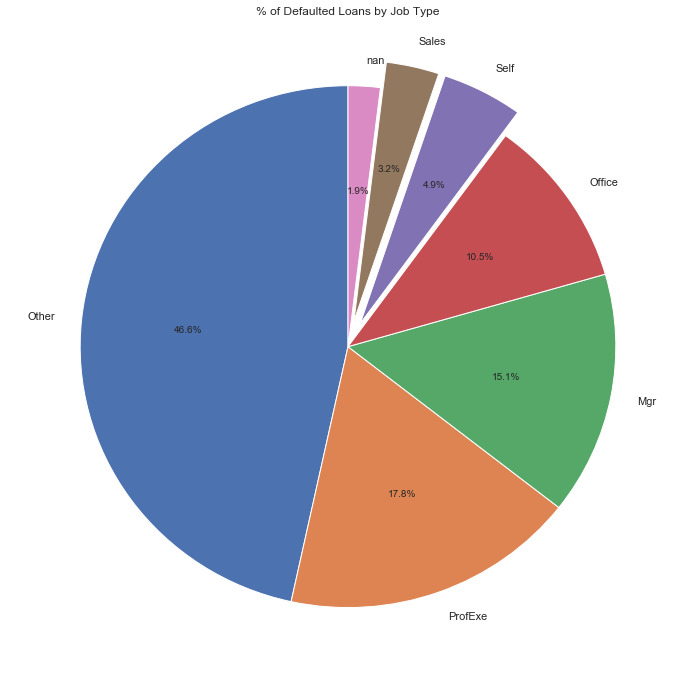

```python
plt.figure(figsize=(12,12))

x = df[df[dflt]==1]["JOB"].value_counts(dropna=False)

chart = plt.pie(
        x,
        labels=x.index,
        startangle=90,
        autopct="%1.1f%%",
        explode=(0,0,0,0,.1,.1,0)
    )

chart = plt.title("% of Defaulted Loans by Job Type")
```

We know that Sales and Self-Employed individuals default at a higher rate and result in higher losses, however the pie chart shows that (excluding missing data) they make up the smallest portions of defaulted loans.

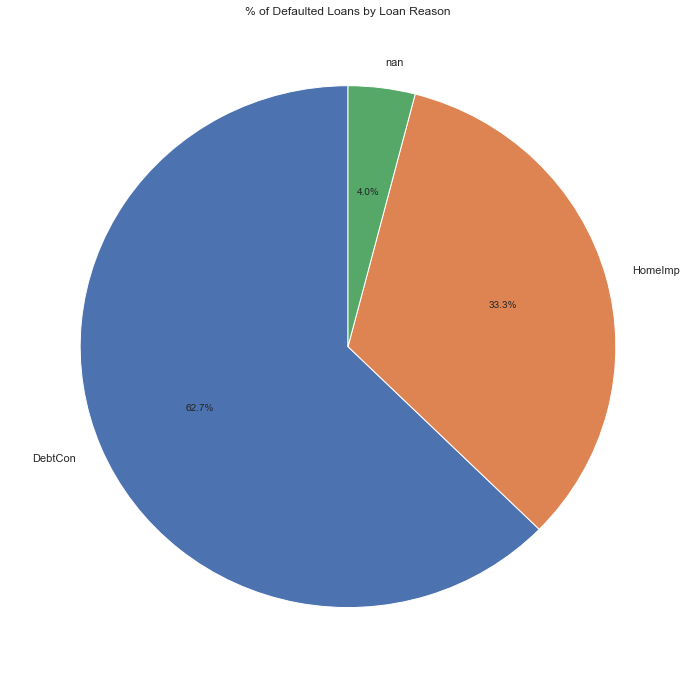

```python
plt.figure(figsize=(12,12))

x = df[df[dflt]==1]["REASON"].value_counts(dropna=False)

chart = plt.pie(
        x,
        labels=x.index,
        startangle=90,
        autopct="%1.1f%%"
    )

chart = plt.title("% of Defaulted Loans by Loan Reason")
```

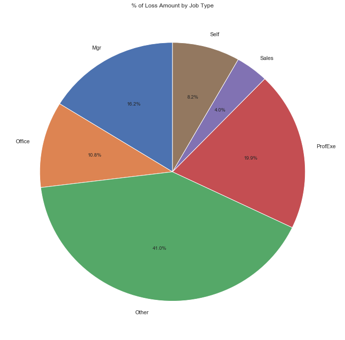

```python
plt.figure(figsize=(12,12))

x = df[[amt,'JOB']].dropna().groupby('JOB').sum()

chart = plt.pie(
        x[amt],
        labels=x.index,
        startangle=90,
        autopct="%1.1f%%"
    )

chart = plt.title("% of Loss Amount by Job Type")
```

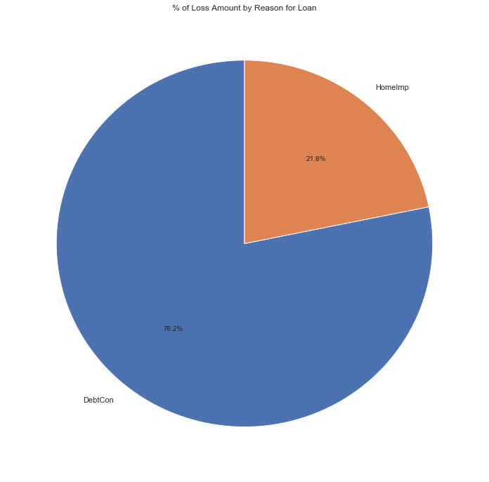

```python
plt.figure(figsize=(12,12))

x = df[[amt,'REASON']].dropna().groupby('REASON').sum()

chart = plt.pie(
        x[amt],
        labels=x.index,
        startangle=90,
        autopct="%1.1f%%"
    )

chart = plt.title("% of Loss Amount by Reason for Loan")
```

Going back to our observation that DebtCon loss on average is about double that of HomeImp loss, this pie chart shows that when considering the total loss combined, DebtCon defaults account for nearly 80%, so close to 4 times the total loss from HomeImp defaults.

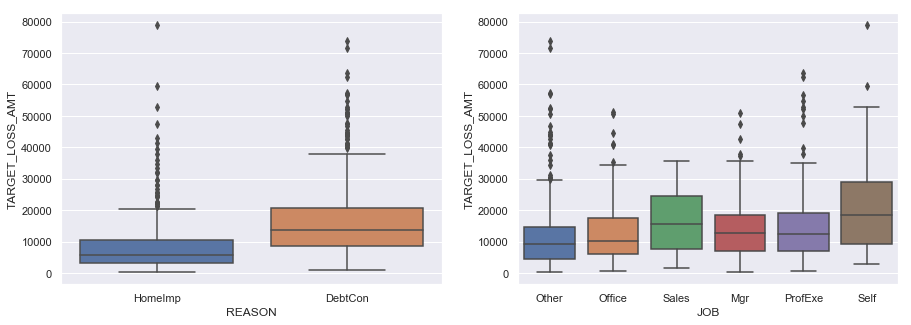

```python
fig, ax = plt.subplots(1, 2, figsize=(15, 5))

for var, subplot in zip(objList, ax.flatten()):
    plot = sns.boxplot(x=var, y=amt, data=df, ax=subplot)
```

The box plots above show that REASON may be a useful variable in determining LOSS, but JOB might be less useful. Given that, we can take a look at the relationships between numerical values and LOSS split up by REASON below.

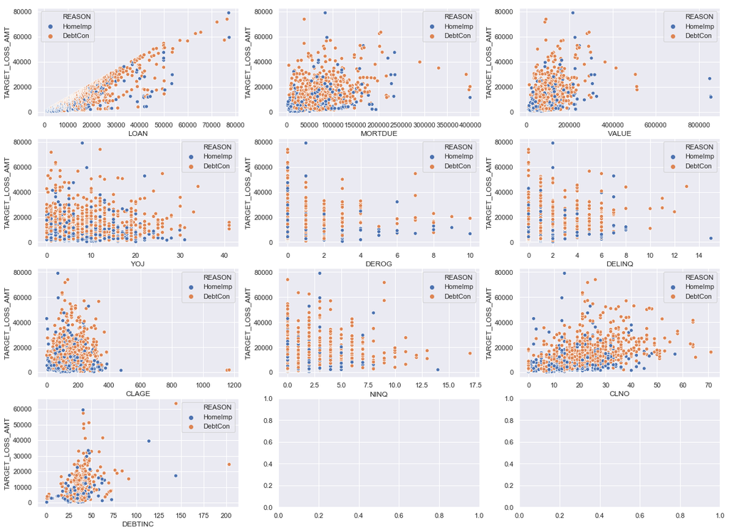

```python
fig, ax = plt.subplots(4, 3, figsize=(20, 15))

for var, subplot in zip(fltList, ax.flatten()):
    plot = sns.scatterplot(x=var, y=amt, data=df, hue='REASON', ax=subplot)
```

The strongest relationship between numerical values and LOSS is the LOAN amount, which makes sense (higher loan amount = risk for higher loss if defaulted).

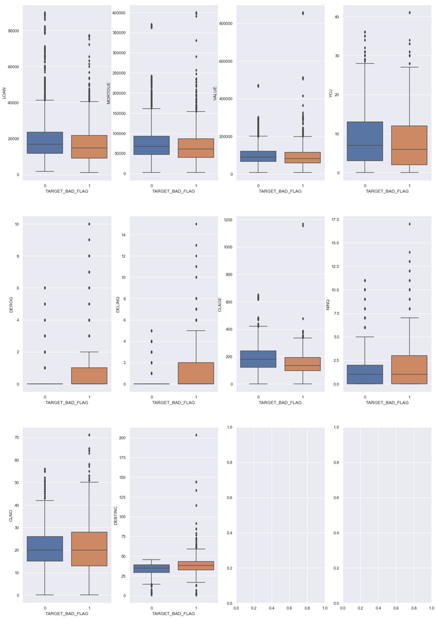

```python
fig, ax = plt.subplots(3, 4, figsize=(20, 30))

for var, subplot in zip(fltList, ax.flatten()):
    plot = sns.boxplot(x=dflt, y=var, data=df, ax=subplot)
```

The above box plots show the differences in numerical values for loans that did not default and those that did. Looking at Delinquencies, we have a lot of outliers but those might be useful since every recipient with more than 6 defaulted in this dataset.

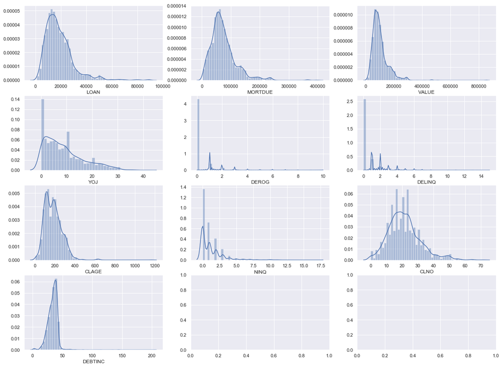

```python
fig, ax = plt.subplots(4, 3, figsize=(20, 15))

for var, subplot in zip(fltList, ax.flatten()):
    plot = sns.distplot(a=df[var], ax=subplot)
```

The histograms above again show which values have the most outliers/extreme outliers by showing the continuous distributions. These visualize the earlier observation that all of these contain extreme outliers.

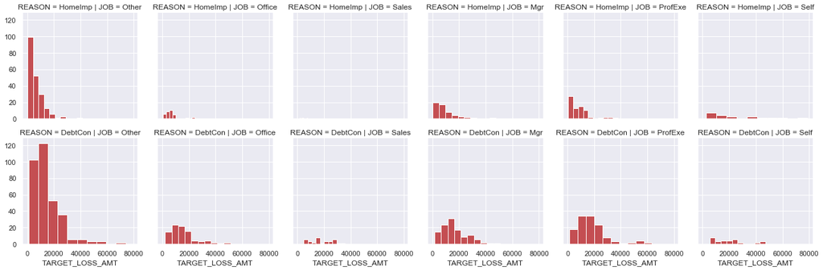

```python
g = sns.FacetGrid(df, col="JOB",  row="REASON")
g = g.map(plt.hist, amt, color="r")
```

Since we only have 2 categorical values, we can look at the LOSS amount of each combination of REASON and JOB. At a glance we can see that, as expected, the DebtCon row's LOSS amounts are all higher than their HomeImp counterparts above. We can also see just how small of a portion the Sales and Self-Employed recipients make up in this dataset.

# Impute Missing Data

```python
print("Categorical Value Count and Missing Values")
print()

for obj in objList:

    print(obj + ' Classes: ' + str(df[obj].unique()))
    print("Missing: " + str(df[obj].isna().sum()))
    g = df.groupby(obj)
    print(g[obj].count())
    print()

print("Missing Numerical Values")
print()

for flt in fltList:

    print(flt + " is Missing " + str(df[flt].isna().sum()))
    print()
```

```
Categorical Value Count and Missing Values

REASON Classes: ['HomeImp' nan 'DebtCon']
Missing: 252
REASON
DebtCon    3928
HomeImp    1780
Name: REASON, dtype: int64

JOB Classes: ['Other' nan 'Office' 'Sales' 'Mgr' 'ProfExe' 'Self']
Missing: 279
JOB
Mgr         767
Office      948
Other      2388
ProfExe    1276
Sales       109
Self        193
Name: JOB, dtype: int64

Missing Numerical Values

LOAN is Missing 0

MORTDUE is Missing 518

VALUE is Missing 112

YOJ is Missing 515

DEROG is Missing 708

DELINQ is Missing 580

CLAGE is Missing 308

NINQ is Missing 510

CLNO is Missing 222

DEBTINC is Missing 1267
```

```python
for obj in objList:

    if df[obj].isna().sum() == 0:

        continue

    print(obj + " is missing values")
    name = "IMP_" + obj
    print(name + " created")
    df[name] = df[obj]
    df[name] = df[name].fillna(value=df[obj].mode()[0])
    print()

# Get the Median numerical values for each class of each categorical value before dropping incase we want to use for imputing.
med_job = df.groupby('JOB').median().T.copy()
med_reason = df.groupby('REASON').median().T.copy()

for obj in objList:

    if df[obj].isna().sum() == 0:

        continue

    df = df.drop(obj, axis=1)
```

```
REASON is missing values
IMP_REASON created

JOB is missing values
IMP_JOB created
```

```python
dt = df.dtypes
objList = []

for var in dt.index:

    if var in ['TARGET_BAD_FLAG','TARGET_LOSS_AMT']:

        continue

    if dt[var] == "object":

        objList.append(var)

for obj in objList:

    y = pd.get_dummies(df[obj], prefix=obj, dummy_na=False)
    df = pd.concat([df, y], axis=1)
    df = df.drop( obj, axis=1)

df
```

|  | TARGET_BAD_FLAG | TARGET_LOSS_AMT | LOAN | MORTDUE | VALUE | YOJ | DEROG | DELINQ | CLAGE | NINQ | CLNO | DEBTINC | IMP_REASON_DebtCon | IMP_REASON_HomeImp | IMP_JOB_Mgr | IMP_JOB_Office | IMP_JOB_Other | IMP_JOB_ProfExe | IMP_JOB_Sales | IMP_JOB_Self |
| --- | --- | --- | --- | --- | --- | --- | --- | --- | --- | --- | --- | --- | --- | --- | --- | --- | --- | --- | --- | --- |
| 0 | 1 | 641.0 | 1100.0 | 25860.0 | 39025.0 | 10.5 | 0.0 | 0.0 | 94.366667 | 1.0 | 9.0 | NaN | 0 | 1 | 0 | 0 | 1 | 0 | 0 | 0 |
| 1 | 1 | 1109.0 | 1300.0 | 70053.0 | 68400.0 | 7.0 | 0.0 | 2.0 | 121.833333 | 0.0 | 14.0 | NaN | 0 | 1 | 0 | 0 | 1 | 0 | 0 | 0 |
| 2 | 1 | 767.0 | 1500.0 | 13500.0 | 16700.0 | 4.0 | 0.0 | 0.0 | 149.466667 | 1.0 | 10.0 | NaN | 0 | 1 | 0 | 0 | 1 | 0 | 0 | 0 |
| 3 | 1 | 1425.0 | 1500.0 | NaN | NaN | NaN | NaN | NaN | NaN | NaN | NaN | NaN | 1 | 0 | 0 | 0 | 1 | 0 | 0 | 0 |
| 4 | 0 | NaN | 1700.0 | 97800.0 | 112000.0 | 3.0 | 0.0 | 0.0 | 93.333333 | 0.0 | 14.0 | NaN | 0 | 1 | 0 | 1 | 0 | 0 | 0 | 0 |
| ... | ... | ... | ... | ... | ... | ... | ... | ... | ... | ... | ... | ... | ... | ... | ... | ... | ... | ... | ... | ... |
| 5955 | 0 | NaN | 88900.0 | 57264.0 | 90185.0 | 16.0 | 0.0 | 0.0 | 221.808717 | 0.0 | 16.0 | 36.112347 | 1 | 0 | 0 | 0 | 1 | 0 | 0 | 0 |
| 5956 | 0 | NaN | 89000.0 | 54576.0 | 92937.0 | 16.0 | 0.0 | 0.0 | 208.692070 | 0.0 | 15.0 | 35.859971 | 1 | 0 | 0 | 0 | 1 | 0 | 0 | 0 |
| 5957 | 0 | NaN | 89200.0 | 54045.0 | 92924.0 | 15.0 | 0.0 | 0.0 | 212.279697 | 0.0 | 15.0 | 35.556590 | 1 | 0 | 0 | 0 | 1 | 0 | 0 | 0 |
| 5958 | 0 | NaN | 89800.0 | 50370.0 | 91861.0 | 14.0 | 0.0 | 0.0 | 213.892709 | 0.0 | 16.0 | 34.340882 | 1 | 0 | 0 | 0 | 1 | 0 | 0 | 0 |
| 5959 | 0 | NaN | 89900.0 | 48811.0 | 88934.0 | 15.0 | 0.0 | 0.0 | 219.601002 | 0.0 | 16.0 | 34.571519 | 1 | 0 | 0 | 0 | 1 | 0 | 0 | 0 |

5960 rows × 20 columns

```python
for flt in fltList:

    if df[flt].isna().sum() == 0:
        continue

    flag = "M_" + flt
    imp = "IMP_" + flt

    df[flag] = df[flt].isna() + 0
    df[imp] = df[flt]

    df.loc[df[imp].isna(), imp] = df[flt].median()

    df = df.drop(flt, axis=1)

df.T
```

|  | 0 | 1 | 2 | 3 | 4 | 5 | 6 | 7 | 8 | 9 | ... | 5950 | 5951 | 5952 | 5953 | 5954 | 5955 | 5956 | 5957 | 5958 | 5959 |
| --- | --- | --- | --- | --- | --- | --- | --- | --- | --- | --- | --- | --- | --- | --- | --- | --- | --- | --- | --- | --- | --- |
| TARGET_BAD_FLAG | 1.000000 | 1.000000 | 1.000000 | 1.000000 | 0.000000 | 1.000000 | 1.000000 | 1.000000 | 1.000000 | 1.000000 | ... | 0.000000 | 0.000000 | 0.000000 | 0.000000 | 0.000000 | 0.000000 | 0.000000 | 0.000000 | 0.000000 | 0.000000 |
| TARGET_LOSS_AMT | 641.000000 | 1109.000000 | 767.000000 | 1425.000000 | NaN | 335.000000 | 1841.000000 | 373.000000 | 1217.000000 | 1523.000000 | ... | NaN | NaN | NaN | NaN | NaN | NaN | NaN | NaN | NaN | NaN |
| LOAN | 1100.000000 | 1300.000000 | 1500.000000 | 1500.000000 | 1700.000000 | 1700.000000 | 1800.000000 | 1800.000000 | 2000.000000 | 2000.000000 | ... | 87500.000000 | 88300.000000 | 88500.000000 | 88800.000000 | 88900.000000 | 88900.000000 | 89000.000000 | 89200.000000 | 89800.000000 | 89900.000000 |
| IMP_REASON_DebtCon | 0.000000 | 0.000000 | 0.000000 | 1.000000 | 0.000000 | 0.000000 | 0.000000 | 0.000000 | 0.000000 | 0.000000 | ... | 1.000000 | 1.000000 | 1.000000 | 1.000000 | 1.000000 | 1.000000 | 1.000000 | 1.000000 | 1.000000 | 1.000000 |
| IMP_REASON_HomeImp | 1.000000 | 1.000000 | 1.000000 | 0.000000 | 1.000000 | 1.000000 | 1.000000 | 1.000000 | 1.000000 | 1.000000 | ... | 0.000000 | 0.000000 | 0.000000 | 0.000000 | 0.000000 | 0.000000 | 0.000000 | 0.000000 | 0.000000 | 0.000000 |
| IMP_JOB_Mgr | 0.000000 | 0.000000 | 0.000000 | 0.000000 | 0.000000 | 0.000000 | 0.000000 | 0.000000 | 0.000000 | 0.000000 | ... | 0.000000 | 0.000000 | 0.000000 | 0.000000 | 0.000000 | 0.000000 | 0.000000 | 0.000000 | 0.000000 | 0.000000 |
| IMP_JOB_Office | 0.000000 | 0.000000 | 0.000000 | 0.000000 | 1.000000 | 0.000000 | 0.000000 | 0.000000 | 0.000000 | 0.000000 | ... | 0.000000 | 0.000000 | 0.000000 | 0.000000 | 0.000000 | 0.000000 | 0.000000 | 0.000000 | 0.000000 | 0.000000 |
| IMP_JOB_Other | 1.000000 | 1.000000 | 1.000000 | 1.000000 | 0.000000 | 1.000000 | 1.000000 | 1.000000 | 1.000000 | 0.000000 | ... | 1.000000 | 1.000000 | 1.000000 | 1.000000 | 1.000000 | 1.000000 | 1.000000 | 1.000000 | 1.000000 | 1.000000 |
| IMP_JOB_ProfExe | 0.000000 | 0.000000 | 0.000000 | 0.000000 | 0.000000 | 0.000000 | 0.000000 | 0.000000 | 0.000000 | 0.000000 | ... | 0.000000 | 0.000000 | 0.000000 | 0.000000 | 0.000000 | 0.000000 | 0.000000 | 0.000000 | 0.000000 | 0.000000 |
| IMP_JOB_Sales | 0.000000 | 0.000000 | 0.000000 | 0.000000 | 0.000000 | 0.000000 | 0.000000 | 0.000000 | 0.000000 | 1.000000 | ... | 0.000000 | 0.000000 | 0.000000 | 0.000000 | 0.000000 | 0.000000 | 0.000000 | 0.000000 | 0.000000 | 0.000000 |
| IMP_JOB_Self | 0.000000 | 0.000000 | 0.000000 | 0.000000 | 0.000000 | 0.000000 | 0.000000 | 0.000000 | 0.000000 | 0.000000 | ... | 0.000000 | 0.000000 | 0.000000 | 0.000000 | 0.000000 | 0.000000 | 0.000000 | 0.000000 | 0.000000 | 0.000000 |
| M_MORTDUE | 0.000000 | 0.000000 | 0.000000 | 1.000000 | 0.000000 | 0.000000 | 0.000000 | 0.000000 | 0.000000 | 1.000000 | ... | 0.000000 | 0.000000 | 0.000000 | 0.000000 | 0.000000 | 0.000000 | 0.000000 | 0.000000 | 0.000000 | 0.000000 |
| IMP_MORTDUE | 25860.000000 | 70053.000000 | 13500.000000 | 65019.000000 | 97800.000000 | 30548.000000 | 48649.000000 | 28502.000000 | 32700.000000 | 65019.000000 | ... | 55938.000000 | 54004.000000 | 50240.000000 | 53307.000000 | 48919.000000 | 57264.000000 | 54576.000000 | 54045.000000 | 50370.000000 | 48811.000000 |
| M_VALUE | 0.000000 | 0.000000 | 0.000000 | 1.000000 | 0.000000 | 0.000000 | 0.000000 | 0.000000 | 0.000000 | 0.000000 | ... | 0.000000 | 0.000000 | 0.000000 | 0.000000 | 0.000000 | 0.000000 | 0.000000 | 0.000000 | 0.000000 | 0.000000 |
| IMP_VALUE | 39025.000000 | 68400.000000 | 16700.000000 | 89235.500000 | 112000.000000 | 40320.000000 | 57037.000000 | 43034.000000 | 46740.000000 | 62250.000000 | ... | 86794.000000 | 94838.000000 | 94687.000000 | 94058.000000 | 93371.000000 | 90185.000000 | 92937.000000 | 92924.000000 | 91861.000000 | 88934.000000 |
| M_YOJ | 0.000000 | 0.000000 | 0.000000 | 1.000000 | 0.000000 | 0.000000 | 0.000000 | 0.000000 | 0.000000 | 0.000000 | ... | 0.000000 | 0.000000 | 0.000000 | 0.000000 | 0.000000 | 0.000000 | 0.000000 | 0.000000 | 0.000000 | 0.000000 |
| IMP_YOJ | 10.500000 | 7.000000 | 4.000000 | 7.000000 | 3.000000 | 9.000000 | 5.000000 | 11.000000 | 3.000000 | 16.000000 | ... | 15.000000 | 16.000000 | 16.000000 | 16.000000 | 15.000000 | 16.000000 | 16.000000 | 15.000000 | 14.000000 | 15.000000 |
| M_DEROG | 0.000000 | 0.000000 | 0.000000 | 1.000000 | 0.000000 | 0.000000 | 0.000000 | 0.000000 | 0.000000 | 0.000000 | ... | 0.000000 | 0.000000 | 0.000000 | 0.000000 | 0.000000 | 0.000000 | 0.000000 | 0.000000 | 0.000000 | 0.000000 |
| IMP_DEROG | 0.000000 | 0.000000 | 0.000000 | 0.000000 | 0.000000 | 0.000000 | 3.000000 | 0.000000 | 0.000000 | 0.000000 | ... | 0.000000 | 0.000000 | 0.000000 | 0.000000 | 0.000000 | 0.000000 | 0.000000 | 0.000000 | 0.000000 | 0.000000 |
| M_DELINQ | 0.000000 | 0.000000 | 0.000000 | 1.000000 | 0.000000 | 0.000000 | 0.000000 | 0.000000 | 0.000000 | 0.000000 | ... | 0.000000 | 0.000000 | 0.000000 | 0.000000 | 0.000000 | 0.000000 | 0.000000 | 0.000000 | 0.000000 | 0.000000 |
| IMP_DELINQ | 0.000000 | 2.000000 | 0.000000 | 0.000000 | 0.000000 | 0.000000 | 2.000000 | 0.000000 | 2.000000 | 0.000000 | ... | 0.000000 | 0.000000 | 0.000000 | 0.000000 | 1.000000 | 0.000000 | 0.000000 | 0.000000 | 0.000000 | 0.000000 |
| M_CLAGE | 0.000000 | 0.000000 | 0.000000 | 1.000000 | 0.000000 | 0.000000 | 0.000000 | 0.000000 | 0.000000 | 0.000000 | ... | 0.000000 | 0.000000 | 0.000000 | 0.000000 | 0.000000 | 0.000000 | 0.000000 | 0.000000 | 0.000000 | 0.000000 |
| IMP_CLAGE | 94.366667 | 121.833333 | 149.466667 | 173.466667 | 93.333333 | 101.466002 | 77.100000 | 88.766030 | 216.933333 | 115.800000 | ... | 223.881040 | 193.702051 | 214.426206 | 218.304978 | 205.650160 | 221.808717 | 208.692070 | 212.279697 | 213.892709 | 219.601002 |
| M_NINQ | 0.000000 | 0.000000 | 0.000000 | 1.000000 | 0.000000 | 0.000000 | 0.000000 | 0.000000 | 0.000000 | 0.000000 | ... | 0.000000 | 0.000000 | 0.000000 | 0.000000 | 0.000000 | 0.000000 | 0.000000 | 0.000000 | 0.000000 | 0.000000 |
| IMP_NINQ | 1.000000 | 0.000000 | 1.000000 | 1.000000 | 0.000000 | 1.000000 | 1.000000 | 0.000000 | 1.000000 | 0.000000 | ... | 0.000000 | 0.000000 | 0.000000 | 0.000000 | 0.000000 | 0.000000 | 0.000000 | 0.000000 | 0.000000 | 0.000000 |
| M_CLNO | 0.000000 | 0.000000 | 0.000000 | 1.000000 | 0.000000 | 0.000000 | 0.000000 | 0.000000 | 0.000000 | 0.000000 | ... | 0.000000 | 0.000000 | 0.000000 | 0.000000 | 0.000000 | 0.000000 | 0.000000 | 0.000000 | 0.000000 | 0.000000 |
| IMP_CLNO | 9.000000 | 14.000000 | 10.000000 | 20.000000 | 14.000000 | 8.000000 | 17.000000 | 8.000000 | 12.000000 | 13.000000 | ... | 16.000000 | 15.000000 | 16.000000 | 15.000000 | 15.000000 | 16.000000 | 15.000000 | 15.000000 | 16.000000 | 16.000000 |
| M_DEBTINC | 1.000000 | 1.000000 | 1.000000 | 1.000000 | 1.000000 | 0.000000 | 1.000000 | 0.000000 | 1.000000 | 1.000000 | ... | 0.000000 | 0.000000 | 0.000000 | 0.000000 | 0.000000 | 0.000000 | 0.000000 | 0.000000 | 0.000000 | 0.000000 |
| IMP_DEBTINC | 34.818262 | 34.818262 | 34.818262 | 34.818262 | 34.818262 | 37.113614 | 34.818262 | 36.884894 | 34.818262 | 34.818262 | ... | 36.753653 | 36.262691 | 34.751158 | 34.242465 | 34.818262 | 36.112347 | 35.859971 | 35.556590 | 34.340882 | 34.571519 |

29 rows × 5960 columns

And now to confirm the dataset contains no more missing input values:

```python
df.info()
```

```
<class 'pandas.core.frame.DataFrame'>
RangeIndex: 5960 entries, 0 to 5959
Data columns (total 29 columns):
 #   Column              Non-Null Count  Dtype
---  ------              --------------  -----
 0   TARGET_BAD_FLAG     5960 non-null   int64
 1   TARGET_LOSS_AMT     1189 non-null   float64
 2   LOAN                5960 non-null   float64
 3   IMP_REASON_DebtCon  5960 non-null   uint8
 4   IMP_REASON_HomeImp  5960 non-null   uint8
 5   IMP_JOB_Mgr         5960 non-null   uint8
 6   IMP_JOB_Office      5960 non-null   uint8
 7   IMP_JOB_Other       5960 non-null   uint8
 8   IMP_JOB_ProfExe     5960 non-null   uint8
 9   IMP_JOB_Sales       5960 non-null   uint8
```

[output cut: 21 more lines]